# Julia

¿Por qué? y ¿cómo?

Author

Affiliation

David Gómez-Castro

Universidad Autónoma de Madrid - ICMAT

Published

March 1, 2025

# ¿Por qué julia?

## ¿Por qué Julia?

Artículo [*why we created Julia*](https://julialang.org/blog/2012/02/why-we-created-julia/)

- Es **código abierto**:

  todo está alojado en GitHub
- Es **reproducible**:

  permite controlar todas las versiones de todos los paquetes
- Es **dinámica**:

  utiliza tipos dinámicos, y la sintaxis es muy sencilla.
- Es **componible**:

  *multiple distach*

## Julia es rápido ([JIT](https://en.wikipedia.org/wiki/Just-in-time_compilation))

[figure not shown]

Eje vertical (tiempo del lenguaje) / (tiempo de ejecución en C)

https://julialang.org/benchmarks/

## Comparación con MATLAB

La sintaxis para vectores y matrices veremos que es muy sencilla.

```julia
A = [1 2 3; 4 5 6]
```

```
2×3 Matrix{Int64}:
 1  2  3
 4  5  6
```

```julia
@show A[1, :];
```

```
A[1, :] = [1, 2, 3]
```

Comparación de sintaxis vectorial

| Función | Julia | MATLAB |
| --- | --- | --- |
| Leer vector | `x[i]` | `x(i)` |
| Leer fila de matriz | `A[i,:]` | `A(i,:)` |
| Resolver sistema lineal | `A\b` | `A\b` |
| Funciones | `f(x)=x^2` | `f = @(x) x^2` |

En [comparación con Python](https://pythonguides.com/python-numpy-matrix/)

# Instalación

En Linux/MacOS ejecute en una terminal

```bash
curl -fsSL https://install.julialang.org | sh
```

En Windows ejecute en una terminal

```powershell
winget install julia -s msstore
```

Más información e instaladores convencionales en la [web de `julia`](https://julialang.org/downloads/)

**Primera ejecución**

Al lanzar julia por primera vez veremos algo así:

[figure not shown]

# El REPL

Cuando lanzamos `julia` en terminal nos encontramos en el REPL (read-eval-print loop)

```bash
julia>
```

Aquí podemos introducir órdenes como las siguientes para obtener el resultado.

## Uso básico

Variables

```julia
x = 2
```

```
2
```

Vectores

```julia
x = [1, 2]
```

```
2-element Vector{Int64}:
 1
 2
```

Matrices

```julia
A = [1 2]
B = [1 2; 3 4]
```

```
2×2 Matrix{Int64}:
 1  2
 3  4
```

Lógica

```julia
if x == 1
    println("x es uno. Está solito.")
elseif x == 2
    println("x es dos. Mejor en pareja.")
else
    println("x es $x. ¡Qué decir!")
end
```

```
x es [1, 2]. ¡Qué decir!
```

Bucles básicos

```julia
for i = 1:2
    println(i^2)
end
```

```
1
4
```

## Scripts

Los scripts de Julia son archivos `.jl`

```julia
a = 1
a = a + 1
println("a=$a")
```

Ejecutamos en terminal de Unix (si julia está bien en el path)

```bash
$ julia MiCodigo.jl
"a=2"
```

O desde dentro de julia

```bash
julia> include("MiCodigo.jl")
"a=2"
```

## Funciones

Podemos definir funciones de varios modos:

```julia
f(x) = x+1
f(1)
```

```
2
```

```julia
g = x -> x+2
g(1)
```

```
3
```

```julia
function h(x)
    return x + 3
end
h(1)
```

```
4
```

## Otro modos del REPL

El REPL tiene varios modos

| modo | terminal | uso | acceso |
| --- | --- | --- | --- |
| julian | `julia>` | cálculos |  |
| help | `help?>` | ayuda | `?` |
| shell | `shell>` | terminal del sistema | `;` |
| pkg | `(@v1.11) pkg>` | gestión de paquetes | `]` |

[Documentación](https://docs.julialang.org/en/v1/stdlib/REPL/)

# IDEs

## [Visual Studio Code](https://code.visualstudio.com)

Para desarrollar código podemos usar [Visual Studio Code con Julia](https://www.julia-vscode.org).

## Jupyter

También podemos utilizar libretas [Jupyter](https://jupyter.org/install)

Para instalar `jupyter` introduzca en una terminal de `julia`

```julia
using Pkg; Pkg.add("IJulia")
```

Para ejecutarlo

```julia
using IJulia; notebook()
```

La primera vez pedirá instalar otros paquetes. Acepte introduciendo `y`.

# Paquetes

## ¿Qué son?

Las funcionalidades avanzadas se cargan con paquetes (Plots, …)

Los paquetes están alojados en GitHub, donde suelen contar con amplia documentación: ejemplo Plots.jl

Para usar un paquete debemos cargarlo, por ejemplo,

```julia
using Plots
```

Los paquetes deben añadidos en el entorno actual. Para añadirlos basta utilizamos el paquete `Pkg.jl` de la siguiente forma

```julia
using Pkg;
Pkg.add("Plots");
```

```julia
using Plots
plot(x -> exp(x))
```

[figure not shown]

```julia
x = [0, 0.1, 1, 2]
y = exp.(x)

using Plots
plot(x, y)
```

[figure not shown]

## La magia de los macros

```
[ Info: Saved animation to /Users/david/Documents/Universidad/[03] Docencia/Curso Julia/curso-intro-julia/src/tmp.gif
```

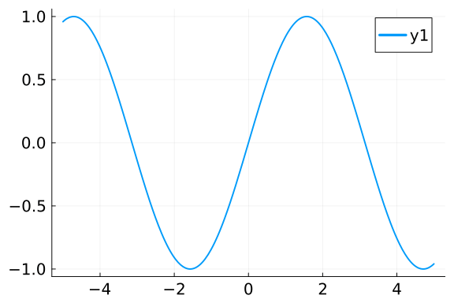

```julia
@gif for n = 1:20
    plot(x -> sin(n * x))
end
```

## La magia del código genérico

Para resolver una EDO podemos usar sintaxis similar a `ode45`

```julia
g = 9.79 # Gravitational constant
L = 1.00 # Length of pendulum

u₀ = [0, π / 60] # Initial speed and angle
tspan = (0.0, 6.3) # Time span

# Define the problem
function pendulum(du, u, p, t)
    θ = u[1]
    dθ = u[2]
    du[1] = dθ
    du[2] = -(g / L) * θ
end

# Pass to solver
using DifferentialEquations
prob = ODEProblem(pendulum, u₀, tspan)
sol = solve(prob, Tsit5(), reltol=1e-6)

# Plot
using Plots
plot(sol.t, first.(sol.u), label="\\theta")
```

[figure not shown]

Tomado de *[The Unreasonable Effectiveness of Multiple Dispatch](https://www.youtube.com/watch?v=kc9HwsxE1OY)*

Sin modificar la librería `DifferentialEquations` podemos extenderla a otros “tipos de datos”

```julia
using Measurements
g = 9.79 ± 0.02 # Gravitational constant
L = 1.00 ± 0.01 # Length of pendulum

u₀ = [0 ± 0.0, π / 60 ± 0.01] # Initial speed and angle
tspan = (0.0, 6.3) # Time span

# Define the problem
function pendulum(du, u, p, t)
    θ = u[1]
    dθ = u[2]
    du[1] = dθ
    du[2] = -(g / L) * θ
end

# Pass to solver
using DifferentialEquations
prob = ODEProblem(pendulum, u₀, tspan)
sol = solve(prob, Tsit5(), reltol=1e-6)

# Plot
using Plots
plot(sol.t, first.(sol.u), label="\\theta")
```

[figure not shown]

Tomado de *[The Unreasonable Effectiveness of Multiple Dispatch](https://www.youtube.com/watch?v=kc9HwsxE1OY)*